# R Notebook

### Model 1: SARIMA (p,d,q)*(P,D,Q)[12] where p = 2, d = 1, q = 1, P = 1, D = 1, Q = 1

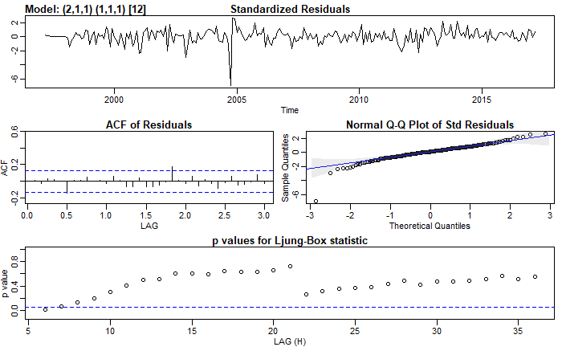

```r
model_1 <- sarima(log(tourism.train), 2,1,1,1,1,1,12)
```

```r
model_1$ttable
```

```
     Estimate     SE  t.value p.value
ar1    0.5682 0.1154   4.9223  0.0000
ar2   -0.1111 0.0777  -1.4298  0.1542
ma1   -0.7838 0.0989  -7.9259  0.0000
sar1  -0.0291 0.0841  -0.3465  0.7293
sma1  -0.7872 0.0615 -12.7916  0.0000
```

In the previous model the p value of the coefficients shows that the null hypothesis against sar1 cannot be rejected. So we will try another model with no seasonal AR coefficient.

### Model 2 : SARIMA (p,d,q)*(P,D,Q)[12] where p = 2, d= 1, q=1, P=0, D=1, Q=1

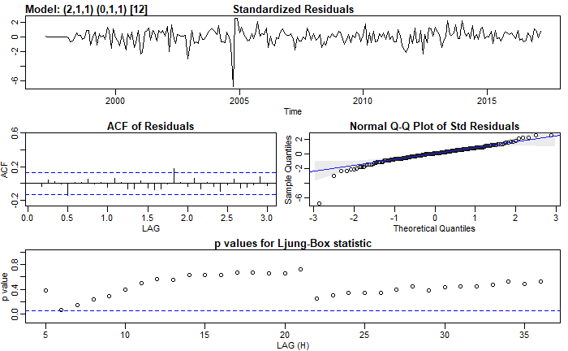

```r
model_2 <- sarima(tourism.train, 2,1,1,0,1,1,12)
```

```r
model_2$ttable
```

```
     Estimate     SE  t.value p.value
ar1    0.5837 0.1140   5.1197  0.0000
ar2   -0.1084 0.0769  -1.4095  0.1601
ma1   -0.7899 0.0967  -8.1666  0.0000
sma1  -0.7860 0.0480 -16.3834  0.0000
```

### Model 3 : SARIMA (p,d,q)*(P,D,Q)[12] where p = 2, d= 1, q=1, P=1, D=3, Q=1

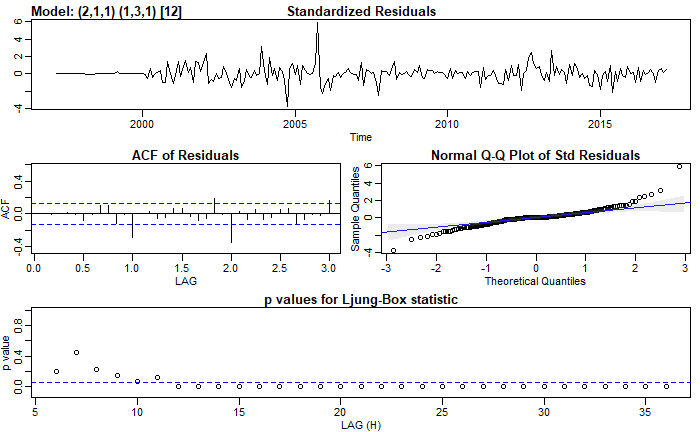

```r
model_3 <- sarima(tourism.train, 2,1,1,1,3,1,12, no.constant = T)
```

```r
model_3
```

```
$fit

Call:
stats::arima(x = xdata, order = c(p, d, q), seasonal = list(order = c(P, D,
    Q), period = S), include.mean = !no.constant, transform.pars = trans, fixed = fixed,
    optim.control = list(trace = trc, REPORT = 1, reltol = tol))

Coefficients:
         ar1      ar2      ma1     sar1     sma1
      0.4010  -0.1729  -0.6529  -0.6326  -0.9981
s.e.  0.1582   0.0893   0.1539   0.0508   0.0459

sigma^2 estimated as 0.01412:  log likelihood = 112.68,  aic = -213.36

$degrees_of_freedom
[1] 199

$ttable
     Estimate     SE  t.value p.value
ar1    0.4010 0.1582   2.5349  0.0120
ar2   -0.1729 0.0893  -1.9369  0.0542
ma1   -0.6529 0.1539  -4.2420  0.0000
sar1  -0.6326 0.0508 -12.4510  0.0000
sma1  -0.9981 0.0459 -21.7280  0.0000

$AIC
[1] -0.9002668

$AICc
[1] -0.8991709

$BIC
[1] -0.8162638
```

```r
model_3$ttable
```

```
     Estimate     SE  t.value p.value
ar1    0.4010 0.1582   2.5349  0.0120
ar2   -0.1729 0.0893  -1.9369  0.0542
ma1   -0.6529 0.1539  -4.2420  0.0000
sar1  -0.6326 0.0508 -12.4510  0.0000
sma1  -0.9981 0.0459 -21.7280  0.0000
```

### Model 4 : SARIMA (p,d,q)*(P,D,Q)[12] where p = 0, d= 0, q=1, P=0, D=2, Q=1

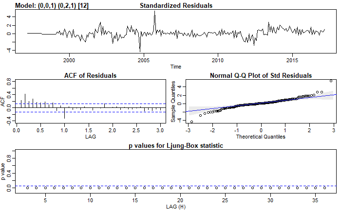

```r
model_4 <- sarima(tourism.train, 0,0,1,0,2,1,12, no.constant = T)
```

```r
model_4
```

```
$fit

Call:
stats::arima(x = xdata, order = c(p, d, q), seasonal = list(order = c(P, D,
    Q), period = S), include.mean = !no.constant, transform.pars = trans, fixed = fixed,
    optim.control = list(trace = trc, REPORT = 1, reltol = tol))

Coefficients:
         ma1     sma1
      0.6086  -1.0000
s.e.  0.0462   0.0572

sigma^2 estimated as 0.009766:  log likelihood = 176.4,  aic = -346.79

$degrees_of_freedom
[1] 215

$ttable
     Estimate     SE  t.value p.value
ma1    0.6086 0.0462  13.1778       0
sma1  -1.0000 0.0572 -17.4886       0

$AIC
[1] -1.45102

$AICc
[1] -1.450807

$BIC
[1] -1.408594
```

```r
model_4$ttable
```

```
     Estimate     SE  t.value p.value
ma1    0.6086 0.0462  13.1778       0
sma1  -1.0000 0.0572 -17.4886       0
```

#### Matrices to judge a forecast.

The RMSE value:

$RMSE= \sqrt{\frac{\sum(y_{pred}-y_{act})^2}{n}}$

As mentioned in the Paper of IJMS, 25/9/2018, Seasonality in Tourism and Forecasting Foreign Tourist Arrival in India, even here we shall measure the Forecast Accuracy using MAPE and RMSE. As mentioned in the paper, “The empirical literature on forecasting suggests using MAPE as it is a good accuracy measure which does not depend on the magnitude of the forecast variable (Mamula, 2015). Lewis (1982) and Baggio & Klobas (2011) suggest a rough scale for the accuracy of a time-series forecasting model based on MAPE – highly accurate (MAPE < 10%), good (10% < MAPE < 20%), reasonable (20% < MAPE < 50%) and inaccurate (MAPE > 50%)” .

A function to show all in one place.

```r
prediction_Sarima <- function(original,train, p,d,q,P,D,Q){
  model <- sarima(train, p,d,q,P,D,Q,12, details = FALSE, no.constant = TRUE)
  model_list <- list(model = c(p,d,q,P,D,Q,12), ttable = model$ttable,
                     AIC = model$AIC, BIC = model$BIC )
  pred <- sarima.for(train, n.ahead = 34 ,p,d,q,P,D,Q,12)
  actual <- window(original, start= c(2017,03), end = c(2020,1))
  rmse <- sqrt(mean(exp(pred$pred)-actual)^2)
  mape <- mean(abs((exp(pred$pred)-actual)/actual))*100
  pred.list <- list(predicted = pred$pred, actual = actual, rmse = rmse , mape = mape)
  return(cat("Model.AIC= ", model_list$AIC, "Model.BIC =", model_list$BIC, "Pred.RMSE= ", pred.list$rmse, "Pred.MAPE=", pred.list$mape, "\n"))

}
```

### Forcasting using various models.

#### Model 1 : SARIMA (2,1,1)X(1,1,1)[12]

We depend our judgement on the following Matrices:

For model : 1. AIC 2. BIC

For forecasted value: 1. RMSE 2. MAPE

```r
prediction_Sarima(tourism, tourism.train, 2,1,1,1,1,1)
```

```
Model.AIC=  -2.324326 Model.BIC = -2.238234 Pred.RMSE=  57715.47 Pred.MAPE= 13.84615
```

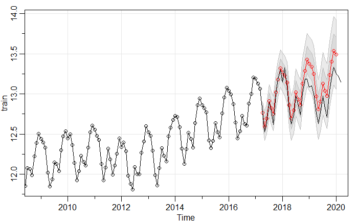

```r
lines(log_tourism)
```

#### Model 2 : SARIMA (2,1,1)X(0,1,1)[12]

```r
prediction_Sarima(tourism, tourism.train, 2,1,1,0,1,1)
```

```
Model.AIC=  -2.332095 Model.BIC = -2.260352 Pred.RMSE=  55744.35 Pred.MAPE= 13.46369
```

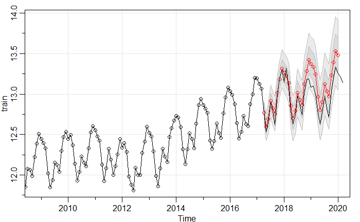

```r
lines(log_tourism)
```

```r
prediction_Sarima(tourism, tourism.train, 1,0,1,0,2,1)
```

```
Model.AIC=  -1.63969 Model.BIC = -1.583123 Pred.RMSE=  11526.16 Pred.MAPE= 7.936613
```

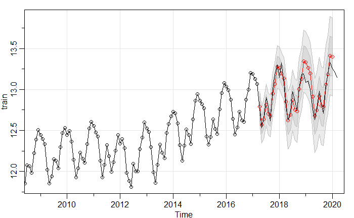

```r
lines(log_tourism)
```

```r
prediction_Sarima(tourism, tourism.train, 0,0,1,0,2,1)
```

```
Model.AIC=  -1.45102 Model.BIC = -1.408594 Pred.RMSE=  2710.62 Pred.MAPE= 8.67875
```

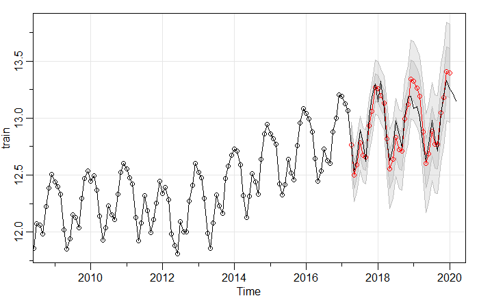

```r
lines(log_tourism)
```